# Opgave 10

## webbog opgave 4.1

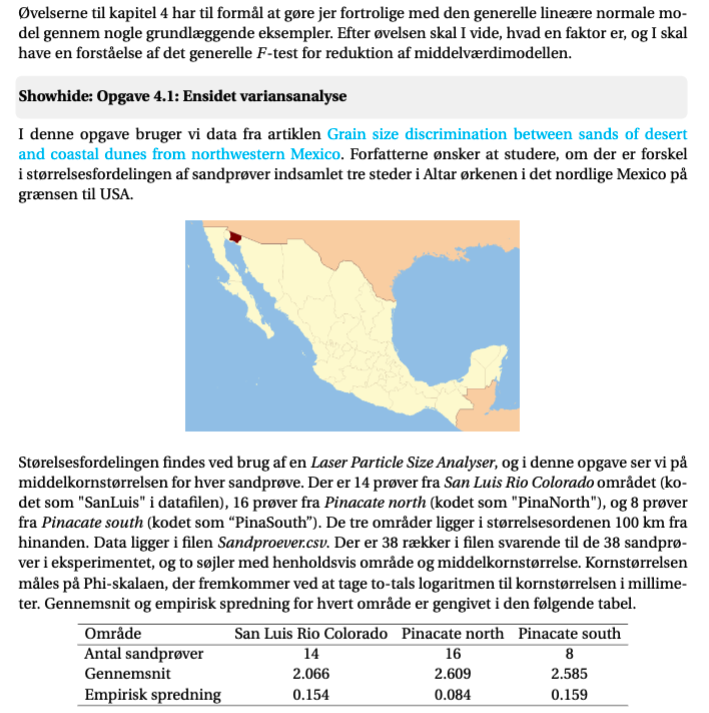

### a) ensider variansanalyse

Indlæs data, og dan de to variableOmraadeogkornstrmed indholdet af de to søj-ler. Undersøg, omOmraadeer en faktor. Svaret afhænger af, hvilken version afRmankører. HvisOmraadeikke er en faktor, skal du omdanne den til en faktor med funk-tionenfactor. Lav en figur, hvorkornstrafsættes modOmraadekodet som 1 til 3(dette kan du gøre ved at brugeas.numeric(Omraade)). Prøv også at lave et qqplotmed kommandoenqqnormFlere(kornstr,Omraade)(se omtalen afqqnormFlerei detskjulte punktBoxplot og qqploti afsnit 4.6) og dernæst et boxplot med kommandoenboxplot(kornstr∼Omraade). Overvej, hvad disse figurer viser om forholdet mellem spred-ningerne i de tre områder og forholdet mellem middelværdierne.

```r
data_a <- read.csv("MatStat-R/data/JLJfiler/Sandproever.csv")
data_a %>% head()
```

```
##      Sted Kornstoerrelse
## 1 SanLuis          2.064
## 2 SanLuis          2.528
## 3 SanLuis          1.960
## 4 SanLuis          2.046
## 5 SanLuis          2.147
## 6 SanLuis          1.947
```

```r
område <- data_a[,1]
class(område)
```

```
## [1] "character"
```

```r
område <- as.factor(område)
class(område)
```

```
## [1] "factor"
```

```r
kornstr <- data_a[,2]
```

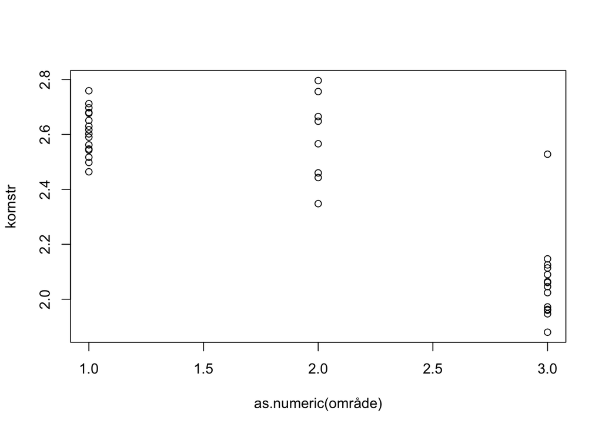

```r
plot(as.numeric(område), kornstr)
```

level 1 og 2 har nogenlunde samme værider.

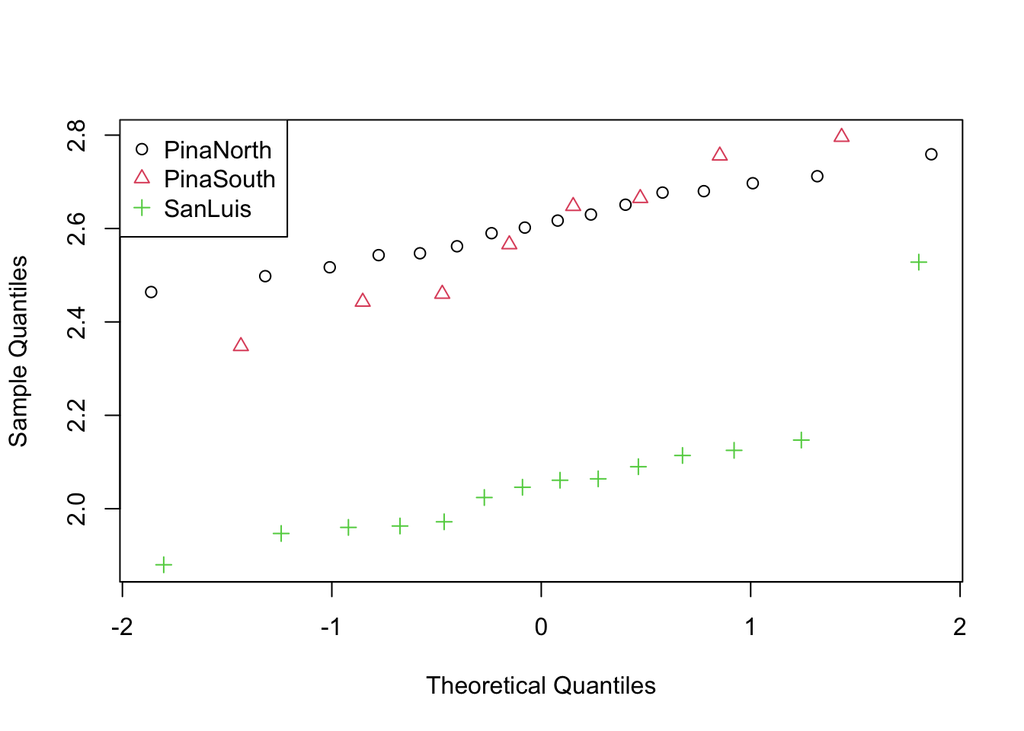

```r
source("MatStat-R/source/Rfunktioner.R")
qqnormFlere(kornstr, område)
```

checker om de følger normal fordeling hvilket de gør.

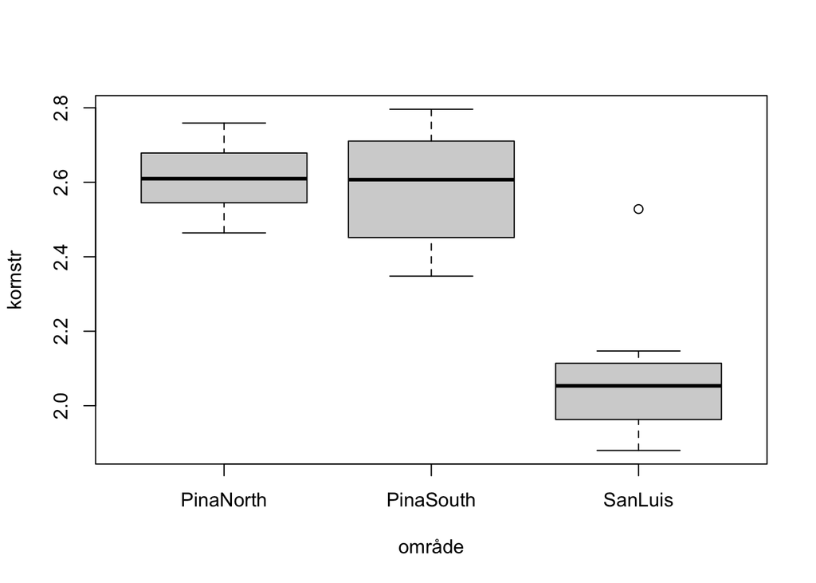

```r
boxplot(kornstr ~ område)
```

hvordan er middelværdier i 1 og 2 er de meget ens men ikke ofr den 3 gruppe. spredning er større for gruppe 2 end for 1 og 3.

### b)

Opskriv den statistiske model, hvor data er delt ind i tre grupper svarende til de tre områder,og data er normalfordelt med en middelværdi og varians, der afhænger af gruppen. Opskriv hypotesen, at de tre varianser er ens. Lav Bartletts test, for at de tre varianser er ens.Hvad bliver konklusionen af testet?

$$M_1 : kornstr \sim N(\mu_{område}, \sigma^2_{område}) ,\ (\mu_1,\mu_2,\mu_3,\sigma_1^2,\sigma^2_2,\sigma^2_3)\in R^3 x R^3$$

Hypotese

$$H0:\sigma^1_1=\sigma^2_2=\sigma^2_3$$
Laver Bartletts tese

```r
bartlett.test(kornstr, område)
```

```
##
##  Bartlett test of homogeneity of variances
##
## data:  kornstr and område
## Bartlett's K-squared = 5.6322, df = 2, p-value = 0.05984
```

P værdien er 0.059 og over 0.05 således data ikke strider mod de har samme varians.

### c)

Opskriv den statistiske model, hvor middelværdien afhænger af området, men de tre vari-anser er ens. Find estimater i denne model (både for middelværdierne og for spredningen).Benyt parametertabellen til at lave ett-test for hypotesen, atμPinaNorth=μPinaSouth.Angiv et 95%-konfidensinterval forμSanLuis−μPinaNorth

$$M_1: kornstr\sim N(\mu_i,\sigma^2), \ (\mu_1,..,\mu_3,\sigma^2)$$

```r
summary(lm(kornstr ~ område - 1)) #parameter tabel
```

```
##
## Call:
## lm(formula = kornstr ~ område - 1)
##
## Residuals:
##      Min       1Q   Median       3Q      Max
## -0.23725 -0.09337 -0.00596  0.06659  0.46221
##
## Coefficients:
##                 Estimate Std. Error t value Pr(>|t|)
## områdePinaNorth  2.60912    0.03245   80.39   <2e-16 ***
## områdePinaSouth  2.58525    0.04590   56.33   <2e-16 ***
## områdeSanLuis    2.06579    0.03470   59.54   <2e-16 ***
## ---
## Signif. codes:  0 '***' 0.001 '**' 0.01 '*' 0.05 '.' 0.1 ' ' 1
##
## Residual standard error: 0.1298 on 35 degrees of freedom
## Multiple R-squared:  0.9974, Adjusted R-squared:  0.9971
## F-statistic:  4393 on 3 and 35 DF,  p-value: < 2.2e-16
```

-1 så man ikke får differencer

```r
summary(lm(kornstr ~ område - 1))$sigma^2
```

```
## [1] 0.01685319
```

bruge parameter tabellen til lave en t test og se på

```r
summary(lm(kornstr ~ område))
```

```
##
## Call:
## lm(formula = kornstr ~ område)
##
## Residuals:
##      Min       1Q   Median       3Q      Max
## -0.23725 -0.09337 -0.00596  0.06659  0.46221
##
## Coefficients:
##                 Estimate Std. Error t value Pr(>|t|)
## (Intercept)      2.60912    0.03245  80.392  < 2e-16 ***
## områdePinaSouth -0.02388    0.05621  -0.425    0.674
## områdeSanLuis   -0.54334    0.04751 -11.437 2.26e-13 ***
## ---
## Signif. codes:  0 '***' 0.001 '**' 0.01 '*' 0.05 '.' 0.1 ' ' 1
##
## Residual standard error: 0.1298 on 35 degrees of freedom
## Multiple R-squared:  0.8114, Adjusted R-squared:  0.8006
## F-statistic: 75.28 on 2 and 35 DF,  p-value: 2.102e-13
```

ser at de to områders middelværdi er ens da pv æride er 0.67 så data stride rikke mode PinaNorth = PinaSourth

```r
confint(lm(kornstr ~ område))
```

```
##                      2.5 %      97.5 %
## (Intercept)      2.5432379  2.67501207
## områdePinaSouth -0.1379947  0.09024475
## områdeSanLuis   -0.6397881 -0.44689049
```

den er områdeSanLuis -0.6397881 -0.44689049

### d)

Opskriv hypotesen, at de tre middelværdier er ens, og lav et test for denne hypotese ved etpassende kald tilanova.Hvad bliver konklusionen i denne opgave: er det rimeligt at sige, at der er samme middel-værdi af middelkornstørrelsen i de tre områder af Altar ørkenen

$$M_1: kornstr\sim N(\mu_i,\sigma^2), \ (\mu,\sigma^2)$$

Hypotesen

$$\mu_1 =\mu_2=\mu_3$$

anova

```r
anova(lm(kornstr ~ område))
```

```
## Analysis of Variance Table
##
## Response: kornstr
##           Df  Sum Sq Mean Sq F value    Pr(>F)
## område     2 2.53748 1.26874  75.282 2.102e-13 ***
## Residuals 35 0.58986 0.01685
## ---
## Signif. codes:  0 '***' 0.001 '**' 0.01 '*' 0.05 '.' 0.1 ' ' 1
```

lav p værdi så den strider mod H0 dermed er de tre middelværdier ikke ens.

Det er også hvad vi så i vores boxplot.

## webbog opgave 4.2 - to sidet varians

I artiklen Environmental heterogeneity does not affect levels of phenotypic plasticity in natu-ral populations of three Drosophila species undersøges, hvordan forskellige arter og geografiskadskilte grupper af bananfluer reagerer på miljøpåvirkninger. I denne opgave skal I se på en del-mængde af data, hvor der betragtes D.melanogasterindsamlet i henholdsvis Danmark og Italien.Fra ægstadiet og frem udsættes fluerne for tre forskellige behandlinger: C (constant), PF (predi-ctable fluctuation) og UF (unpredictalbe fluctuation). For C-gruppen holdes temperaturen kon-stant på 23 (grader celsius) hen over døgnet, for PF følger temperaturen en sinuskurve med mak-simum på 18 og minimum på 13, og for UF følger temperaturen også en sinuskurve, men medstokastiske maksimum og minimum for hvert døgn. Ved en given alder udsættes fluerne for enkritisk varmepåvirkning (37.5 grader celsius uafbrudt), og tiden (minutter) indtil fluen går i komaregistreres. Med undersøgelsen ønsker man således at se, om forskel i opvæksten har betydningfor deres evne til at klare varmepåvirkningen, og om der er forskel i de to geografiske populatio-ner med hensyn til denne evne. Gennemsnit og empirisk spredning for logaritmen til tiden indtilkoma er gengivet for hver kombination af land og behandling i nedenstående tabel.

Data i artiklen kan findes underDryad Digital Repository. Data til opgaven her er i filenBanan-fluer.csv, hvor søjle 1 angiver land, søjle 2 angiver behandling og søjle 3 angiver tiden i minutter,indtil fluen går i koma.

```r
data_b <- read.csv("MatStat-R/data/JLJfiler/Bananfluer.csv")
data_b %>% head()
```

```
##   Land Behandling    Tid
## 1   DK         PF 108.23
## 2   DK         PF 129.17
## 3   DK         PF  69.83
## 4   DK         PF 119.33
## 5   DK         PF  31.93
## 6   DK         PF 204.00
```

### a) additivit plot

Du skal først se på, om tidsmålingerne kan beskrives med en normalfordeling, eller om manførst bør tage logaritmen til tidsmålingerne. Indlæs data og dan variableneLand,Behand-lingogtid. HvisLandogBehandlingikke er faktorer efter indlæsningen, skal du omdan-ne dem til faktorer. Lav qqplots fortidfor alle seks kombinationer af land og behandlingmed kommandoenqqnormFlere(tid,Land:Behandling)(se omtalen afqqnormFlereidet skjulte punktBoxplot og qqploti afsnit 4.6). Lav dernæst tilsvarende qqplot for loga-ritmen tiltid.Hvad bliver din konklusion ud fra de to figurer ?

Lav dernæst interaktionsplot for logaritmen til tiden i forhold til de to faktorer land og be-handling (se omtalen af funktionenadditivitetsPloti det skjulte punktInteraktionsplotiafsnit 4.6).

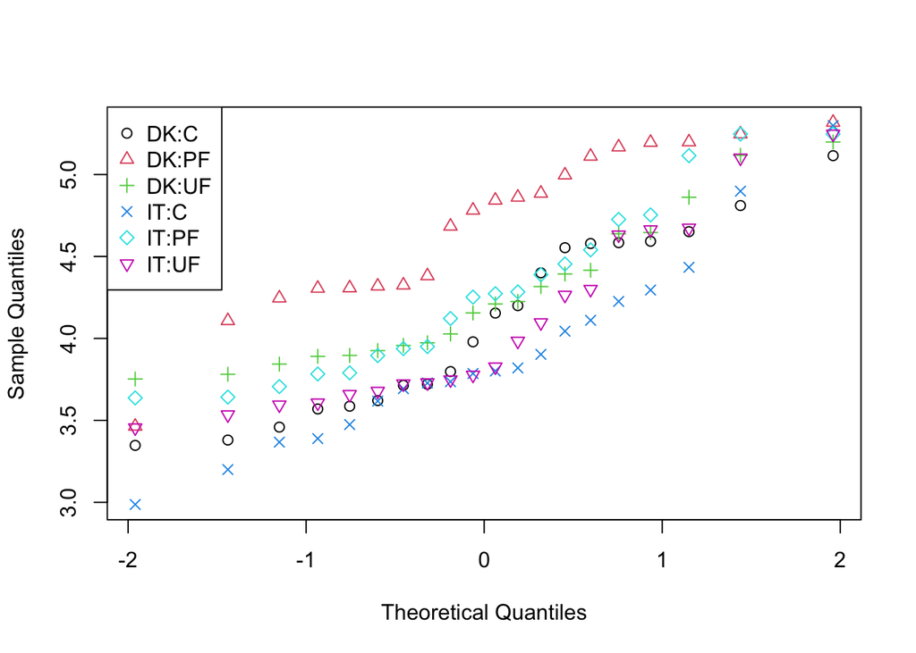

```r
land <- as.factor(data_b$Land)
behandlign <- as.factor(data_b$Behandling)
tid <- log(data_b$Tid)

qqnormFlere(tid, land:behandlign)
```

mere normal når vi bruger log.

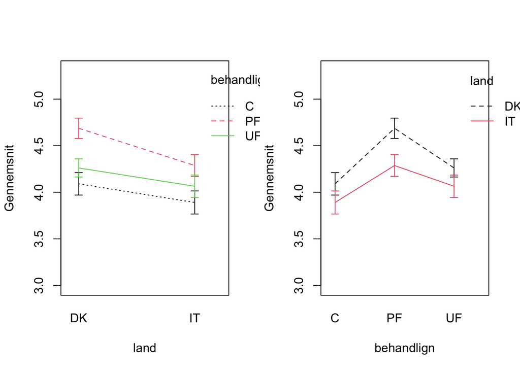

```r
par(mfrow = c(1,2))
additivitetsPlot(land, behandlign, tid)
additivitetsPlot(behandlign, land, tid)
```

Her ser vi de tre behandlinger, venstre side er er de danske fluer mens højre er de italienske. stregen forbinder puntkerne. den anden plot er vi kan e de forskellige behandling. italien har laver levetid ved alle behandlinger.. Dem med den konstante behandling har lavere levetid.

### b)

Opskriv modellen, hvor logaritmen til tidsmålingen hørende til hver gruppe bestemt af landog behandling følger sin egen normalfordeling.Opskriv hypotesen, at varianserne i de 6 grupper er ens, og lav Bartletts test for denne hy-potese. Er det rimeligt at sige, at de seks varianser er ens ?

$$logtid_i \sim N(\mu_{L_i,B_i}, {\sigma^2_{L_i,B_i}})$$

```r
bartlett.test(tid ~ land)
```

```
##
##  Bartlett test of homogeneity of variances
##
## data:  tid by land
## Bartlett's K-squared = 0.017735, df = 1, p-value = 0.8941
```

```r
bartlett.test(tid ~ behandlign)
```

```
##
##  Bartlett test of homogeneity of variances
##
## data:  tid by behandlign
## Bartlett's K-squared = 0.4877, df = 2, p-value = 0.7836
```

Vi laver en barlet test for tid på land og behandling.

### c) ens varians

Opskriv modellen, hvor logaritmen til tiden er normalfordelt, og hver gruppe bestemt afland og behandling har sin egen middelværdi, og alle har den samme varians. Opskriv indenfor denne model additivitetshypotesen, hvor middelværdien består af et bidrag fra land oget bidrag fra behandling.Lav et test, for at data kan beskrives med den additive model. Hvad bliver konklusionen aftestet ? Stemmer konklusionen, med hvad du kan se i interaktionsplottet ?

$$logtid_i \sim N(\mu_{L_i,B_i}, {\sigma^2})$$

```r
m2 <- lm(tid~ land + behandlign)
summary(m2)
```

```
##
## Call:
## lm(formula = tid ~ land + behandlign)
##
## Residuals:
##      Min       1Q   Median       3Q      Max
## -1.15656 -0.40025 -0.07667  0.37276  1.44058
##
## Coefficients:
##              Estimate Std. Error t value Pr(>|t|)
## (Intercept)    4.1235     0.0934  44.147  < 2e-16 ***
## landIT        -0.2657     0.0934  -2.845  0.00525 **
## behandlignPF   0.4966     0.1144   4.342 3.04e-05 ***
## behandlignUF   0.1723     0.1144   1.506  0.13473
## ---
## Signif. codes:  0 '***' 0.001 '**' 0.01 '*' 0.05 '.' 0.1 ' ' 1
##
## Residual standard error: 0.5116 on 116 degrees of freedom
## Multiple R-squared:  0.1918, Adjusted R-squared:  0.1709
## F-statistic: 9.177 on 3 and 116 DF,  p-value: 1.694e-05
```

Siden vi går ud fra de har ens varians så bruger vi t testen

```r
m1tilm2 <- anova(lm(tid ~ land + behandlign), lm(tid ~ land:behandlign))
m1tilm2
```

```
## Analysis of Variance Table
##
## Model 1: tid ~ land + behandlign
## Model 2: tid ~ land:behandlign
##   Res.Df    RSS Df Sum of Sq      F Pr(>F)
## 1    116 30.360
## 2    114 30.088  2   0.27106 0.5135 0.5998
```

høj p værdi så vi kan bruge den additive model.

### d)

Lav et test for henholdsvis ingen effekt af behandling og ingen effekt af land inden for denadditive model.

```r
m2tilm3behandling <- anova(lm(tid ~ land), lm(tid ~ land + behandlign))
m2tilm3land <- anova(lm(tid ~ behandlign), lm(tid ~ land + behandlign))
m2tilm3behandling
```

```
## Analysis of Variance Table
##
## Model 1: tid ~ land
## Model 2: tid ~ land + behandlign
##   Res.Df    RSS Df Sum of Sq      F    Pr(>F)
## 1    118 35.447
## 2    116 30.360  2    5.0872 9.7188 0.0001252 ***
## ---
## Signif. codes:  0 '***' 0.001 '**' 0.01 '*' 0.05 '.' 0.1 ' ' 1
```

```r
m2tilm3land
```

```
## Analysis of Variance Table
##
## Model 1: tid ~ behandlign
## Model 2: tid ~ land + behandlign
##   Res.Df    RSS Df Sum of Sq      F   Pr(>F)
## 1    117 32.478
## 2    116 30.360  1    2.1183 8.0937 0.005253 **
## ---
## Signif. codes:  0 '***' 0.001 '**' 0.01 '*' 0.05 '.' 0.1 ' ' 1
```

### e)

Angiv inden for den addititve model et 95%-konfidensinterval for forskellen i middelværdiaf logaritmen til tiden mellem de to lande.Oversæt det fundne interval til et interval for forholdet mellem middelværdierne af tid indtilkoma for de to lande, jævnfør underafsnit 2.13.3.

## webbog opgave 4.5

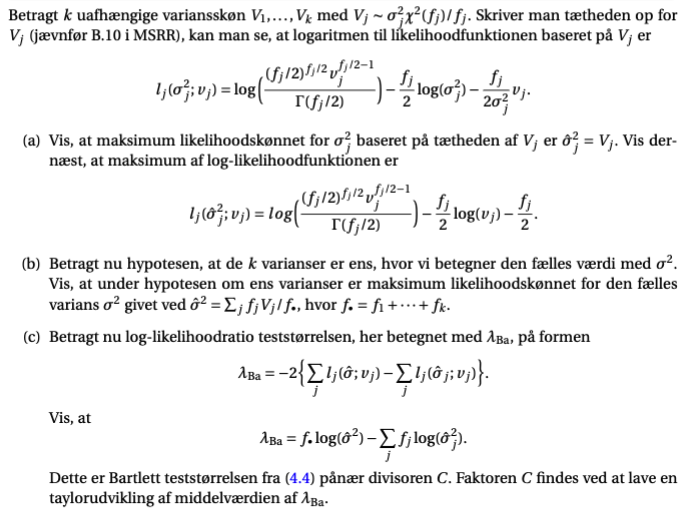

## webbog opgave 4.6

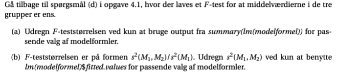

### a)

```r
anova(lm(kornstr ~ 1), lm(kornstr ~ område)) # rigtig 75
```

```
## Analysis of Variance Table
##
## Model 1: kornstr ~ 1
## Model 2: kornstr ~ område
##   Res.Df     RSS Df Sum of Sq      F    Pr(>F)
## 1     37 3.12734
## 2     35 0.58986  2    2.5375 75.282 2.102e-13 ***
## ---
## Signif. codes:  0 '***' 0.001 '**' 0.01 '*' 0.05 '.' 0.1 ' ' 1
```

```r
model_sum_1 <- summary(lm(kornstr ~ 1))
model_sum_2 <- summary(lm(kornstr ~ område))
ssd2 <- model_sum_1$sigma^2*model_sum_1$df[2]
ssd1 <- model_sum_2$sigma^2*model_sum_2$df[2]

((ssd2 - ssd1) /
  (model_sum_1$df[2] - model_sum_2$df[2])) /
  (ssd1 / 35)
```

```
## [1] 75.28181
```

### b) fitted values

```r
# find
((ssd2 - ssd1) /
  (model_sum_1$df[2] - model_sum_2$df[2]))
```

```
## [1] 1.268739
```

Fra de fittede værdie

```r
sum((lm(kornstr ~ område)$fitted.values -
      lm(kornstr ~ 1)$fitted.values)^2) /
  (model_sum_1$df[2] - model_sum_2$df[2])
```

```
## [1] 1.268739
```

## webbog opgave 4.8

Gå tilbage til spørgsmål (e) i opgave 4.2, hvor der findes et konfidensinterval for forskellen i mid-delværdi af logaritmen til tiden mellem de to lande. Beregn dette interval baseret på den infor-mation du får fra et passende kald tilsummary(lm(modelformel)).

$$(\bar X - \bar Y)+- q \sqrt{\frac{S_1^2}{n_1} + \frac{S_2^2}{n_2}}$$

```r
lmUD <- lm(tid ~ land + behandlign)
sumUD <- summary(lmUD)
sumUD
```

```
##
## Call:
## lm(formula = tid ~ land + behandlign)
##
## Residuals:
##      Min       1Q   Median       3Q      Max
## -1.15656 -0.40025 -0.07667  0.37276  1.44058
##
## Coefficients:
##              Estimate Std. Error t value Pr(>|t|)
## (Intercept)    4.1235     0.0934  44.147  < 2e-16 ***
## landIT        -0.2657     0.0934  -2.845  0.00525 **
## behandlignPF   0.4966     0.1144   4.342 3.04e-05 ***
## behandlignUF   0.1723     0.1144   1.506  0.13473
## ---
## Signif. codes:  0 '***' 0.001 '**' 0.01 '*' 0.05 '.' 0.1 ' ' 1
##
## Residual standard error: 0.5116 on 116 degrees of freedom
## Multiple R-squared:  0.1918, Adjusted R-squared:  0.1709
## F-statistic: 9.177 on 3 and 116 DF,  p-value: 1.694e-05
```

```r
diff_mean <- lmUD$coefficients["landIT"]

q <- qt(0.975, 116)
S_1 <- sumUD$sigma
n <- 60
diff_mean - q * (sqrt((S_1^2/n)+(S_1^2/n)))
```

```
##     landIT
## -0.4507197
```

```r
confint(lmUD)
```

```
##                    2.5 %      97.5 %
## (Intercept)   3.93846888  4.30845916
## landIT       -0.45071971 -0.08072943
## behandlignPF  0.27007251  0.72321620
## behandlignUF -0.05426779  0.39887591
```